# compound Final

## Compound

### To rank the top ten US cities (with more than 1 million residents) according to the following criteria:

- population growth
- job growth
- affordability (per capita income vs average real estate prices)
- decline in real estate prices since peak prices

**Importing Libraries**

```python
import numpy as np
import pandas as pd
import matplotlib.pyplot as plt
%matplotlib inline
```

**Importing Dataset**

```python
df1 = pd.read_csv('top_ten.csv')
df1.head(4)
```

|  | Rank | Name | State | 2018 Population | 2016 Population | 2010 Census | Change | 2018 Density |
| --- | --- | --- | --- | --- | --- | --- | --- | --- |
| 0 | 1 | New York | New York | 8580015 | 8537673 | 8175133 | 0.002474 | 11029.232130 |
| 1 | 2 | Los Angeles | California | 4030668 | 3976322 | 3792621 | 0.006787 | 3320.644797 |
| 2 | 3 | Chicago | Illinois | 2687682 | 2704958 | 2695598 | -0.003204 | 4564.612213 |
| 3 | 4 | Houston | Texas | 2340814 | 2303482 | 2099451 | 0.008038 | 1419.917805 |

**Lets Rename the Column names for easy usage**

```python
df1.columns = map(str.lower, df1.columns)
df1.rename({"2018 population":"2018_population","2016 population":"2016_population","2010 census":"2010_population","change":"avg_pop_growth","2018 density":"2018_density","name":"city"}, inplace = True, axis = 1)
df1.head()
```

|  | rank | city | state | 2018_population | 2016_population | 2010_population | avg_pop_growth | 2018_density |
| --- | --- | --- | --- | --- | --- | --- | --- | --- |
| 0 | 1 | New York | New York | 8580015 | 8537673 | 8175133 | 0.002474 | 11029.232130 |
| 1 | 2 | Los Angeles | California | 4030668 | 3976322 | 3792621 | 0.006787 | 3320.644797 |
| 2 | 3 | Chicago | Illinois | 2687682 | 2704958 | 2695598 | -0.003204 | 4564.612213 |
| 3 | 4 | Houston | Texas | 2340814 | 2303482 | 2099451 | 0.008038 | 1419.917805 |
| 4 | 5 | Phoenix | Arizona | 1679243 | 1615017 | 1445632 | 0.019496 | 1252.474383 |

**Lets Deal with cities with more than 1 Million Residents as mentioned in the question**

```python
df1 = df1.loc[(df1['2018_population'] > 1000000)]
df1
```

|  | rank | city | state | 2018_population | 2016_population | 2010_population | avg_pop_growth | 2018_density |
| --- | --- | --- | --- | --- | --- | --- | --- | --- |
| 0 | 1 | New York | New York | 8580015 | 8537673 | 8175133 | 0.002474 | 11029.232130 |
| 1 | 2 | Los Angeles | California | 4030668 | 3976322 | 3792621 | 0.006787 | 3320.644797 |
| 2 | 3 | Chicago | Illinois | 2687682 | 2704958 | 2695598 | -0.003204 | 4564.612213 |
| 3 | 4 | Houston | Texas | 2340814 | 2303482 | 2099451 | 0.008038 | 1419.917805 |
| 4 | 5 | Phoenix | Arizona | 1679243 | 1615017 | 1445632 | 0.019496 | 1252.474383 |
| 5 | 6 | Philadelphia | Pennsylvania | 1573688 | 1567872 | 1526006 | 0.001851 | 4528.337442 |
| 6 | 7 | San Antonio | Texas | 1541456 | 1492510 | 1327407 | 0.016133 | 1291.083266 |
| 7 | 8 | San Diego | California | 1438060 | 1406630 | 1307402 | 0.011049 | 1709.720503 |
| 8 | 9 | Dallas | Texas | 1359133 | 1317929 | 1197816 | 0.015391 | 1543.608793 |
| 9 | 10 | San Jose | California | 1030796 | 1025350 | 945942 | 0.002649 | 2242.032634 |

**cleaning of data is not much required**

```python
del df1['2010_population']
del df1['rank']
df1
```

|  | city | state | 2018_population | 2016_population | avg_pop_growth | 2018_density |
| --- | --- | --- | --- | --- | --- | --- |
| 0 | New York | New York | 8580015 | 8537673 | 0.002474 | 11029.232130 |
| 1 | Los Angeles | California | 4030668 | 3976322 | 0.006787 | 3320.644797 |
| 2 | Chicago | Illinois | 2687682 | 2704958 | -0.003204 | 4564.612213 |
| 3 | Houston | Texas | 2340814 | 2303482 | 0.008038 | 1419.917805 |
| 4 | Phoenix | Arizona | 1679243 | 1615017 | 0.019496 | 1252.474383 |
| 5 | Philadelphia | Pennsylvania | 1573688 | 1567872 | 0.001851 | 4528.337442 |
| 6 | San Antonio | Texas | 1541456 | 1492510 | 0.016133 | 1291.083266 |
| 7 | San Diego | California | 1438060 | 1406630 | 0.011049 | 1709.720503 |
| 8 | Dallas | Texas | 1359133 | 1317929 | 0.015391 | 1543.608793 |
| 9 | San Jose | California | 1030796 | 1025350 | 0.002649 | 2242.032634 |

**According to "Forbes", "WalletHub","Apartmentlist.com" I am adding relevant columns in helping us to rank the cities**

```python
job_growth = [2, 2.6, 1.5, 0.1, 3.3, 2.2, 2.9, 2.6, 3.9, 3.1]
median_income = [64605,61931,65999,61444,58173,50702,55576,70141,62673,107290]
median_homeprice = [385700,533900,258600,233500,244300,163500,215100,594300,265800,1122900]
unemployment = [4.3,4.6,4.5,5.5,4.4,5.7,3.9,4.2,4.0,3.4]
rental_rate = [1.0,1.9,-0.8,3.4,2.2,1.2,0.9,1.8,1.1,2.2]
real_estate_ranking = [258,150,254,165,135,232,249,83,36,61]
columns = [job_growth,median_income,median_homeprice,unemployment,rental_rate,real_estate_ranking]
column_names = ['job_growth','median_income','median_homeprice','unemployment','rental_rate','real_estate_ranking']
for i in range(0,6):
    df1[column_names[i]] = columns[i]
df1
```

|  | city | state | 2018_population | 2016_population | avg_pop_growth | 2018_density | job_growth | median_income | median_homeprice | unemployment | rental_rate | real_estate_ranking |
| --- | --- | --- | --- | --- | --- | --- | --- | --- | --- | --- | --- | --- |
| 0 | New York | New York | 8580015 | 8537673 | 0.002474 | 11029.232130 | 2.0 | 64605 | 385700 | 4.3 | 1.0 | 258 |
| 1 | Los Angeles | California | 4030668 | 3976322 | 0.006787 | 3320.644797 | 2.6 | 61931 | 533900 | 4.6 | 1.9 | 150 |
| 2 | Chicago | Illinois | 2687682 | 2704958 | -0.003204 | 4564.612213 | 1.5 | 65999 | 258600 | 4.5 | -0.8 | 254 |
| 3 | Houston | Texas | 2340814 | 2303482 | 0.008038 | 1419.917805 | 0.1 | 61444 | 233500 | 5.5 | 3.4 | 165 |
| 4 | Phoenix | Arizona | 1679243 | 1615017 | 0.019496 | 1252.474383 | 3.3 | 58173 | 244300 | 4.4 | 2.2 | 135 |
| 5 | Philadelphia | Pennsylvania | 1573688 | 1567872 | 0.001851 | 4528.337442 | 2.2 | 50702 | 163500 | 5.7 | 1.2 | 232 |
| 6 | San Antonio | Texas | 1541456 | 1492510 | 0.016133 | 1291.083266 | 2.9 | 55576 | 215100 | 3.9 | 0.9 | 249 |
| 7 | San Diego | California | 1438060 | 1406630 | 0.011049 | 1709.720503 | 2.6 | 70141 | 594300 | 4.2 | 1.8 | 83 |
| 8 | Dallas | Texas | 1359133 | 1317929 | 0.015391 | 1543.608793 | 3.9 | 62673 | 265800 | 4.0 | 1.1 | 36 |
| 9 | San Jose | California | 1030796 | 1025350 | 0.002649 | 2242.032634 | 3.1 | 107290 | 1122900 | 3.4 | 2.2 | 61 |

**1. Ranking cities according to population growth**

```python
pg = df1.nlargest(10,'avg_pop_growth')
idx = 0
idy = 2
rank = [1,2,3,4,5,6,7,8,9,10]
weightage = [10,9,8,7,6,5,4,3,2,1]
pg.insert(loc=idx, column='score', value=weightage)
pg.insert(loc=idx, column='rank', value=rank)
pg["points"] = pg.score * 7
pg = pg.reindex(['points'] + list(pg.columns[:14]), axis=1)
pg
```

[output not shown]

**2. Ranking Cities according to job growth**

```python
jg = df1.nlargest(10, 'job_growth')
idx = 0
rank = [1,2,3,4,5,6,7,8,9,10]
weightage = [10,9,8,7,6,5,4,3,2,1]
jg.insert(loc=idx, column='score', value=weightage)
jg.insert(loc=idx, column='rank', value=rank)
jg["points"] = jg.score * 5
jg = jg.reindex(['points'] + list(jg.columns[:14]), axis=1)
jg
```

[output not shown]

**3. Ranking cities according to Easy Affordability**

```python
df1['affordability'] = df1.median_homeprice - df1.median_income
af = df1.nsmallest(10,'affordability')
idx = 0
rank = [1,2,3,4,5,6,7,8,9,10]
weightage = [10,9,8,7,6,5,4,3,2,1]
af.insert(loc=idx, column='score', value=weightage)
af.insert(loc=idx, column='rank', value=rank)
af["points"] = af.score * 6
af = af.reindex(['points'] + list(af.columns[:15]), axis=1)
af
```

|  | points | rank | score | city | state | 2018_population | 2016_population | avg_pop_growth | 2018_density | job_growth | median_income | median_homeprice | unemployment | rental_rate | real_estate_ranking | affordability |
| --- | --- | --- | --- | --- | --- | --- | --- | --- | --- | --- | --- | --- | --- | --- | --- | --- |
| 5 | 60 | 1 | 10 | Philadelphia | Pennsylvania | 1573688 | 1567872 | 0.001851 | 4528.337442 | 2.2 | 50702 | 163500 | 5.7 | 1.2 | 232 | 112798 |
| 6 | 54 | 2 | 9 | San Antonio | Texas | 1541456 | 1492510 | 0.016133 | 1291.083266 | 2.9 | 55576 | 215100 | 3.9 | 0.9 | 249 | 159524 |
| 3 | 48 | 3 | 8 | Houston | Texas | 2340814 | 2303482 | 0.008038 | 1419.917805 | 0.1 | 61444 | 233500 | 5.5 | 3.4 | 165 | 172056 |
| 4 | 42 | 4 | 7 | Phoenix | Arizona | 1679243 | 1615017 | 0.019496 | 1252.474383 | 3.3 | 58173 | 244300 | 4.4 | 2.2 | 135 | 186127 |
| 2 | 36 | 5 | 6 | Chicago | Illinois | 2687682 | 2704958 | -0.003204 | 4564.612213 | 1.5 | 65999 | 258600 | 4.5 | -0.8 | 254 | 192601 |
| 8 | 30 | 6 | 5 | Dallas | Texas | 1359133 | 1317929 | 0.015391 | 1543.608793 | 3.9 | 62673 | 265800 | 4.0 | 1.1 | 36 | 203127 |
| 0 | 24 | 7 | 4 | New York | New York | 8580015 | 8537673 | 0.002474 | 11029.232130 | 2.0 | 64605 | 385700 | 4.3 | 1.0 | 258 | 321095 |
| 1 | 18 | 8 | 3 | Los Angeles | California | 4030668 | 3976322 | 0.006787 | 3320.644797 | 2.6 | 61931 | 533900 | 4.6 | 1.9 | 150 | 471969 |
| 7 | 12 | 9 | 2 | San Diego | California | 1438060 | 1406630 | 0.011049 | 1709.720503 | 2.6 | 70141 | 594300 | 4.2 | 1.8 | 83 | 524159 |
| 9 | 6 | 10 | 1 | San Jose | California | 1030796 | 1025350 | 0.002649 | 2242.032634 | 3.1 | 107290 | 1122900 | 3.4 | 2.2 | 61 | 1015610 |

*By this its clear that people in Philadelphia can highly afford their own home by their Average Income*

**4. Ranking cities according to medium size home Increased rental rates**

```python
rr = df1.nlargest(10,'rental_rate')
idx = 0
rank = [1,2,3,4,5,6,7,8,9,10]
weightage = [10,9,8,7,6,5,4,3,2,1]
rr.insert(loc=idx, column='score', value=weightage)
rr.insert(loc=idx, column='rank', value=rank)
rr["points"] = rr.score * 2
rr = rr.reindex(['points'] + list(rr.columns[:15]), axis=1)
rr
```

|  | points | rank | score | city | state | 2018_population | 2016_population | avg_pop_growth | 2018_density | job_growth | median_income | median_homeprice | unemployment | rental_rate | real_estate_ranking | affordability |
| --- | --- | --- | --- | --- | --- | --- | --- | --- | --- | --- | --- | --- | --- | --- | --- | --- |
| 3 | 20 | 1 | 10 | Houston | Texas | 2340814 | 2303482 | 0.008038 | 1419.917805 | 0.1 | 61444 | 233500 | 5.5 | 3.4 | 165 | 172056 |
| 4 | 18 | 2 | 9 | Phoenix | Arizona | 1679243 | 1615017 | 0.019496 | 1252.474383 | 3.3 | 58173 | 244300 | 4.4 | 2.2 | 135 | 186127 |
| 9 | 16 | 3 | 8 | San Jose | California | 1030796 | 1025350 | 0.002649 | 2242.032634 | 3.1 | 107290 | 1122900 | 3.4 | 2.2 | 61 | 1015610 |
| 1 | 14 | 4 | 7 | Los Angeles | California | 4030668 | 3976322 | 0.006787 | 3320.644797 | 2.6 | 61931 | 533900 | 4.6 | 1.9 | 150 | 471969 |
| 7 | 12 | 5 | 6 | San Diego | California | 1438060 | 1406630 | 0.011049 | 1709.720503 | 2.6 | 70141 | 594300 | 4.2 | 1.8 | 83 | 524159 |
| 5 | 10 | 6 | 5 | Philadelphia | Pennsylvania | 1573688 | 1567872 | 0.001851 | 4528.337442 | 2.2 | 50702 | 163500 | 5.7 | 1.2 | 232 | 112798 |
| 8 | 8 | 7 | 4 | Dallas | Texas | 1359133 | 1317929 | 0.015391 | 1543.608793 | 3.9 | 62673 | 265800 | 4.0 | 1.1 | 36 | 203127 |
| 0 | 6 | 8 | 3 | New York | New York | 8580015 | 8537673 | 0.002474 | 11029.232130 | 2.0 | 64605 | 385700 | 4.3 | 1.0 | 258 | 321095 |
| 6 | 4 | 9 | 2 | San Antonio | Texas | 1541456 | 1492510 | 0.016133 | 1291.083266 | 2.9 | 55576 | 215100 | 3.9 | 0.9 | 249 | 159524 |
| 2 | 2 | 10 | 1 | Chicago | Illinois | 2687682 | 2704958 | -0.003204 | 4564.612213 | 1.5 | 65999 | 258600 | 4.5 | -0.8 | 254 | 192601 |

**5. Ranking cities according to RealEstate Market Ranking in that particular place**

```python
rer = df1.nsmallest(10,'real_estate_ranking')
idx = 0
rank = [1,2,3,4,5,6,7,8,9,10]
weightage = [10,9,8,7,6,5,4,3,2,1]
rer.insert(loc=idx, column='score', value=weightage)
rer.insert(loc=idx, column='rank', value=rank)
rer["points"] = rer.score * 3
rer = rer.reindex(['points'] + list(rer.columns[:15]), axis=1)
rer
```

|  | points | rank | score | city | state | 2018_population | 2016_population | avg_pop_growth | 2018_density | job_growth | median_income | median_homeprice | unemployment | rental_rate | real_estate_ranking | affordability |
| --- | --- | --- | --- | --- | --- | --- | --- | --- | --- | --- | --- | --- | --- | --- | --- | --- |
| 8 | 30 | 1 | 10 | Dallas | Texas | 1359133 | 1317929 | 0.015391 | 1543.608793 | 3.9 | 62673 | 265800 | 4.0 | 1.1 | 36 | 203127 |
| 9 | 27 | 2 | 9 | San Jose | California | 1030796 | 1025350 | 0.002649 | 2242.032634 | 3.1 | 107290 | 1122900 | 3.4 | 2.2 | 61 | 1015610 |
| 7 | 24 | 3 | 8 | San Diego | California | 1438060 | 1406630 | 0.011049 | 1709.720503 | 2.6 | 70141 | 594300 | 4.2 | 1.8 | 83 | 524159 |
| 4 | 21 | 4 | 7 | Phoenix | Arizona | 1679243 | 1615017 | 0.019496 | 1252.474383 | 3.3 | 58173 | 244300 | 4.4 | 2.2 | 135 | 186127 |
| 1 | 18 | 5 | 6 | Los Angeles | California | 4030668 | 3976322 | 0.006787 | 3320.644797 | 2.6 | 61931 | 533900 | 4.6 | 1.9 | 150 | 471969 |
| 3 | 15 | 6 | 5 | Houston | Texas | 2340814 | 2303482 | 0.008038 | 1419.917805 | 0.1 | 61444 | 233500 | 5.5 | 3.4 | 165 | 172056 |
| 5 | 12 | 7 | 4 | Philadelphia | Pennsylvania | 1573688 | 1567872 | 0.001851 | 4528.337442 | 2.2 | 50702 | 163500 | 5.7 | 1.2 | 232 | 112798 |
| 6 | 9 | 8 | 3 | San Antonio | Texas | 1541456 | 1492510 | 0.016133 | 1291.083266 | 2.9 | 55576 | 215100 | 3.9 | 0.9 | 249 | 159524 |
| 2 | 6 | 9 | 2 | Chicago | Illinois | 2687682 | 2704958 | -0.003204 | 4564.612213 | 1.5 | 65999 | 258600 | 4.5 | -0.8 | 254 | 192601 |
| 0 | 3 | 10 | 1 | New York | New York | 8580015 | 8537673 | 0.002474 | 11029.232130 | 2.0 | 64605 | 385700 | 4.3 | 1.0 | 258 | 321095 |

**6. Ranking Cities according to Unemployment Ratio**

```python
ue = df1.nsmallest(10,'unemployment')
idx = 0
rank = [1,2,3,4,5,6,7,8,9,10]
weightage = [10,9,8,7,6,5,4,3,2,1]
ue.insert(loc=idx, column='score', value=weightage)
ue.insert(loc=idx, column='rank', value=rank)
ue["points"] = ue.score * 1
ue = ue.reindex(['points'] + list(ue.columns[:15]), axis=1)
ue
```

|  | points | rank | score | city | state | 2018_population | 2016_population | avg_pop_growth | 2018_density | job_growth | median_income | median_homeprice | unemployment | rental_rate | real_estate_ranking | affordability |
| --- | --- | --- | --- | --- | --- | --- | --- | --- | --- | --- | --- | --- | --- | --- | --- | --- |
| 9 | 10 | 1 | 10 | San Jose | California | 1030796 | 1025350 | 0.002649 | 2242.032634 | 3.1 | 107290 | 1122900 | 3.4 | 2.2 | 61 | 1015610 |
| 6 | 9 | 2 | 9 | San Antonio | Texas | 1541456 | 1492510 | 0.016133 | 1291.083266 | 2.9 | 55576 | 215100 | 3.9 | 0.9 | 249 | 159524 |
| 8 | 8 | 3 | 8 | Dallas | Texas | 1359133 | 1317929 | 0.015391 | 1543.608793 | 3.9 | 62673 | 265800 | 4.0 | 1.1 | 36 | 203127 |
| 7 | 7 | 4 | 7 | San Diego | California | 1438060 | 1406630 | 0.011049 | 1709.720503 | 2.6 | 70141 | 594300 | 4.2 | 1.8 | 83 | 524159 |
| 0 | 6 | 5 | 6 | New York | New York | 8580015 | 8537673 | 0.002474 | 11029.232130 | 2.0 | 64605 | 385700 | 4.3 | 1.0 | 258 | 321095 |
| 4 | 5 | 6 | 5 | Phoenix | Arizona | 1679243 | 1615017 | 0.019496 | 1252.474383 | 3.3 | 58173 | 244300 | 4.4 | 2.2 | 135 | 186127 |
| 2 | 4 | 7 | 4 | Chicago | Illinois | 2687682 | 2704958 | -0.003204 | 4564.612213 | 1.5 | 65999 | 258600 | 4.5 | -0.8 | 254 | 192601 |
| 1 | 3 | 8 | 3 | Los Angeles | California | 4030668 | 3976322 | 0.006787 | 3320.644797 | 2.6 | 61931 | 533900 | 4.6 | 1.9 | 150 | 471969 |
| 3 | 2 | 9 | 2 | Houston | Texas | 2340814 | 2303482 | 0.008038 | 1419.917805 | 0.1 | 61444 | 233500 | 5.5 | 3.4 | 165 | 172056 |
| 5 | 1 | 10 | 1 | Philadelphia | Pennsylvania | 1573688 | 1567872 | 0.001851 | 4528.337442 | 2.2 | 50702 | 163500 | 5.7 | 1.2 | 232 | 112798 |

**7. Ranking cities according to population Density**

```python
df1['2018_density'] = df1['2018_density'] * 0.386102
```

```python
p_den = df1.nsmallest(10,'2018_density')
idx = 0
rank = [1,2,3,4,5,6,7,8,9,10]
weightage = [10,9,8,7,6,5,4,3,2,1]
p_den.insert(loc=idx, column='score', value=weightage)
p_den.insert(loc=idx, column='rank', value=rank)
p_den["points"] = p_den.score * 4
p_den = p_den.reindex(['points'] + list(p_den.columns[:15]), axis=1)
p_den
```

|  | points | rank | score | city | state | 2018_population | 2016_population | avg_pop_growth | 2018_density | job_growth | median_income | median_homeprice | unemployment | rental_rate | real_estate_ranking | affordability |
| --- | --- | --- | --- | --- | --- | --- | --- | --- | --- | --- | --- | --- | --- | --- | --- | --- |
| 4 | 40 | 1 | 10 | Phoenix | Arizona | 1679243 | 1615017 | 0.019496 | 483.582864 | 3.3 | 58173 | 244300 | 4.4 | 2.2 | 135 | 186127 |
| 6 | 36 | 2 | 9 | San Antonio | Texas | 1541456 | 1492510 | 0.016133 | 498.489831 | 2.9 | 55576 | 215100 | 3.9 | 0.9 | 249 | 159524 |
| 3 | 32 | 3 | 8 | Houston | Texas | 2340814 | 2303482 | 0.008038 | 548.233104 | 0.1 | 61444 | 233500 | 5.5 | 3.4 | 165 | 172056 |
| 8 | 28 | 4 | 7 | Dallas | Texas | 1359133 | 1317929 | 0.015391 | 595.990442 | 3.9 | 62673 | 265800 | 4.0 | 1.1 | 36 | 203127 |
| 7 | 24 | 5 | 6 | San Diego | California | 1438060 | 1406630 | 0.011049 | 660.126506 | 2.6 | 70141 | 594300 | 4.2 | 1.8 | 83 | 524159 |
| 9 | 20 | 6 | 5 | San Jose | California | 1030796 | 1025350 | 0.002649 | 865.653284 | 3.1 | 107290 | 1122900 | 3.4 | 2.2 | 61 | 1015610 |
| 1 | 16 | 7 | 4 | Los Angeles | California | 4030668 | 3976322 | 0.006787 | 1282.107597 | 2.6 | 61931 | 533900 | 4.6 | 1.9 | 150 | 471969 |
| 5 | 12 | 8 | 3 | Philadelphia | Pennsylvania | 1573688 | 1567872 | 0.001851 | 1748.400143 | 2.2 | 50702 | 163500 | 5.7 | 1.2 | 232 | 112798 |
| 2 | 8 | 9 | 2 | Chicago | Illinois | 2687682 | 2704958 | -0.003204 | 1762.405905 | 1.5 | 65999 | 258600 | 4.5 | -0.8 | 254 | 192601 |
| 0 | 4 | 10 | 1 | New York | New York | 8580015 | 8537673 | 0.002474 | 4258.408584 | 2.0 | 64605 | 385700 | 4.3 | 1.0 | 258 | 321095 |

- Here we can see Phoenix top's the list being less denser, by this we can say that there is more available area for construction and other development purpose which will be useful for our investor to buy land at a cheap rate initially

**Since a Investor wants to Know how to Overall Rank these cities with the above criteria Iam Giving score to each and every city aaccording to their rank, score lies from 10 to 1 for city with rank 1 to 10.**

**Weightage to every criteria is mentioned below taking investor's point of view which various from individual to individual and can be modified later**

1. Population growth = 7
2. Affordability = 6
3. Job growth = 5
4. Less Population Density = 4
5. Real Estate Market Ranking = 3
6. Rental Rates = 2
7. Unemployment = 1

**Now lets get the overall score for each city**

```python
dict_1 = {'Phoenix':[],'San Antonio ':[],'Houston ':[],'Dallas ':[],'San Diego':[],'San Jose':[],'Los Angeles':[],'Philadelphia':[],'Chicago ':[],'New York ':[]}

for i in range(0,10):
    dict_1[af['city'][i]].append(af['points'][i])
    dict_1[p_den['city'][i]].append(p_den['points'][i])
    dict_1[ue['city'][i]].append(ue['points'][i])
    dict_1[rr['city'][i]].append(rr['points'][i])
    dict_1[rer['city'][i]].append(rer['points'][i])
    dict_1[pg['city'][i]].append(pg['points'][i])
    dict_1[jg['city'][i]].append(jg['points'][i])

dict_1
```

```
{'Phoenix': [42, 40, 5, 18, 21, 70, 45],
 'San Antonio ': [54, 36, 9, 4, 9, 63, 35],
 'Houston ': [48, 32, 2, 20, 15, 42, 5],
 'Dallas ': [30, 28, 8, 8, 30, 56, 50],
 'San Diego': [12, 24, 7, 12, 24, 49, 25],
 'San Jose': [6, 20, 10, 16, 27, 28, 40],
 'Los Angeles': [18, 16, 3, 14, 18, 35, 30],
 'Philadelphia': [60, 12, 1, 10, 12, 14, 20],
 'Chicago ': [36, 8, 4, 2, 6, 7, 10],
 'New York ': [24, 4, 6, 6, 3, 21, 15]}
```

```python
city = ['Phoenix','San Antonio ','Houston ','Dallas ','San Diego','San Jose','Los Angeles','Philadelphia','Chicago ','New York ']
dict_2 = {'Phoenix':[],'San Antonio ':[],'Houston ':[],'Dallas ':[],'San Diego':[],'San Jose':[],'Los Angeles':[],'Philadelphia':[],'Chicago ':[],'New York ':[]}
for j in range(0,10):
    dict_2[city[j]] = sum(dict_1[city[j]])

dict_2
```

```
{'Phoenix': 241,
 'San Antonio ': 210,
 'Houston ': 164,
 'Dallas ': 210,
 'San Diego': 153,
 'San Jose': 147,
 'Los Angeles': 134,
 'Philadelphia': 129,
 'Chicago ': 73,
 'New York ': 79}
```

```python
import warnings
warnings.filterwarnings("ignore")
a = [1,2,3,4,5,6,7,8,9,10]
point =sorted(dict_2.values(), reverse = True)
cities = []
for i in range(10):
    cities.append(list(dict_2.keys())[list(dict_2.values()).index(point[i])])

df_3 = pd.DataFrame({'rank':a,'score':point,'City':cities})
df_3['City'][2] = 'Dallas'
df_3
```

|  | rank | score | City |
| --- | --- | --- | --- |
| 0 | 1 | 241 | Phoenix |
| 1 | 2 | 210 | San Antonio |
| 2 | 3 | 210 | Dallas |
| 3 | 4 | 164 | Houston |
| 4 | 5 | 153 | San Diego |
| 5 | 6 | 147 | San Jose |
| 6 | 7 | 134 | Los Angeles |
| 7 | 8 | 129 | Philadelphia |
| 8 | 9 | 79 | New York |
| 9 | 10 | 73 | Chicago |

## Data Visiualization

**1. Population Growth Graph**

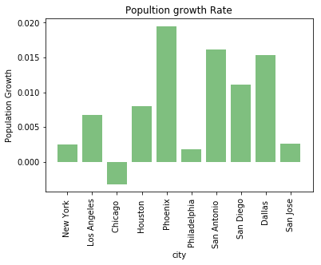

```python
plt.bar(df1.city, df1.avg_pop_growth, align='center', alpha=0.5, color = 'green')
plt.xticks( rotation = 90)
plt.xlabel('city')
plt.ylabel('Population Growth')
plt.title('Popultion growth Rate')
plt.show()
```

**2. Job growth graph**

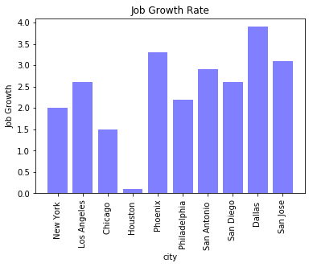

```python
plt.bar(df1.city, df1.job_growth, align='center', alpha=0.5, color = 'Blue')
plt.xticks( rotation = 90)
plt.xlabel('city')
plt.ylabel('Job Growth')
plt.title('Job Growth Rate')
plt.show()
```

**3. Affordability Graph**

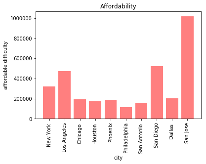

```python
plt.bar(df1.city, df1.affordability, align='center', alpha=0.5, color = 'red')
plt.xticks( rotation = 90)
plt.xlabel('city')
plt.ylabel('affordable difficulty')
plt.title('Affordability')
plt.show()
```

**4. Cities Vs Rental Rates**

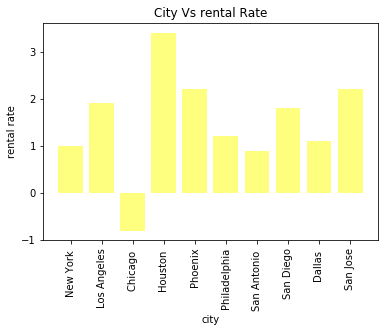

```python
plt.bar(df1.city, df1.rental_rate, align='center', alpha=0.5, color = 'yellow')
plt.xticks( rotation = 90)
plt.xlabel('city')
plt.ylabel('rental rate')
plt.title('City Vs rental Rate')
plt.show()
```

**5. Real Estate Ranking**

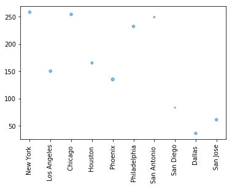

```python
np.random.seed(19680801)
N = 50
x = df1.city
y = df1.real_estate_ranking
area = (30 * np.random.rand(N)) # 0 to 15 point radii
plt.xticks( rotation = 90)
plt.scatter(x, y, s=area, alpha=0.5)
plt.show()
```

**6. Unemployment Ratio Graph**

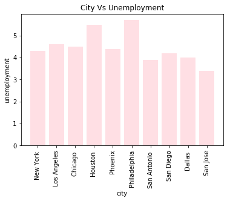

```python
plt.bar(df1.city, df1.unemployment, align='center', alpha=0.5, color = 'pink')
plt.xticks( rotation = 90)
plt.xlabel('city')
plt.ylabel('unemployment')
plt.title('City Vs Unemployment')
plt.show()
```

**7. Population Density Graph**

[figure not shown]

```python
plt.bar(df1.city, df1["2018_density"], align='center', alpha=0.5, color = 'gold')
plt.xticks( rotation = 90)
plt.xlabel('city')
plt.ylabel('population density')
plt.title('City Vs population density')
plt.show()
```

**Top 10 U.S. cities with the best growth, employment, and business opportunities(having more than 1 Million residents)**

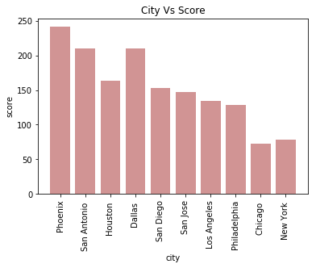

|  | rank | score | City |
| --- | --- | --- | --- |
| 0 | 1 | 241 | Phoenix |
| 1 | 2 | 210 | San Antonio |
| 2 | 3 | 210 | Dallas |
| 3 | 4 | 164 | Houston |
| 4 | 5 | 153 | San Diego |
| 5 | 6 | 147 | San Jose |
| 6 | 7 | 134 | Los Angeles |
| 7 | 8 | 129 | Philadelphia |
| 8 | 9 | 79 | New York |
| 9 | 10 | 73 | Chicago |

```python
plt.bar(dict_2.keys(),dict_2.values(), align='center', alpha=0.5, color = 'brown')
plt.xticks( rotation = 90)
plt.xlabel('city')
plt.ylabel('score')
plt.title('City Vs Score')
plt.show()
df_3
```

*By this we can say that Pheonix has the highest score of 241 and ranked 1st Position*

**Top 10 U.S. cities with the best growth, employment, and business opportunities(having more than 1 Million residents)**

```python
a = [1,2,3,4,5,6,7,8,9,10]
point =sorted(dict_2.values(), reverse = True)
cities = []
for i in range(10):
    cities.append(list(dict_2.keys())[list(dict_2.values()).index(point[i])])

df_3 = pd.DataFrame({'rank':a,'score':point,'City':cities})
df_3
```

[output not shown]

**Conclusion**

The above results are drawn by giving weightage to every factor and score for each city according to their ranks while considering every factor. These weightage are given by looking at the business perspective of an investor. This weightage may vary for every different perspective and different purposes.

**Referance**

- Dataset : https://www.kaggle.com/muonneutrino/us-census-demographic-data
- Rental rates : https://docs.google.com/spreadsheets/d/1eqCtTK0T0pSmTihu_ETUMKdzLdLMH3yZ12OaD_3tSnQ/edit#gid=0
- https://www.apartmentlist.com/rentonomics/rents-growing-fastest/
- Real Estate Market Raking: https://wallethub.com/edu/best-real-estate-markets/14889/#
- US city population growth: http://worldpopulationreview.com/us-cities/
- Job growth, affordability: Forbes about each city

**Acknowledgements**

The data from Kaggle were collected by the US Census Bureau. As a product of the US federal government, this is not subject to copyright within the US.